# STAT245 Project

Lin Lee Cheong & Terence Tam

August 11, 2017

## 1. About the data

The data is equally divided between control and test groups, and for each group it is also evenly divided between pre-experiment and post-experiment data.

```r
# Number of entries in data set
nrow(userLevel)
```

```
## [1] 1021288
```

```r
# Number of entries between control and test group (0 for control, 1 for test')
table(userLevel$Group)
```

```
##
##      0      1
## 510486 510802
```

```r
# 'Number of entries between control/test and pre/post-experiment data'
table(userLevel$Group, userLevel$IsPreExperiment)
```

```
##
##          0      1
##   0 260181 250305
##   1 260014 250788
```

For ease of use later, we first separate dataset into control and test group.

```r
control_group <- userLevel[userLevel$Group == 0, ]
test_group <- userLevel[userLevel$Group == 1, ]
```

## 2 Hypothesis testing:

The 5 parameters we would like to apply hypothesis testing are: PV, numDays, numVisits, sumX, sumY.

The null hypothesis (H0) we would like to test is that there is no difference in the means between control and test group. So H0: mean(control) - mean(test) = 0 for each of the parameters

```r
userLevel %>%
  select(-UserID) %>%
  filter(IsPreExperiment == 0) %>%
  group_by(Group) %>%
  summarise_all(mean)
```

```
## # A tibble: 2 × 7
##   Group IsPreExperiment       PV  numDays numVisits    sumX     sumY
##   <int>           <dbl>    <dbl>    <dbl>     <dbl>   <dbl>    <dbl>
## 1     0               0 7.178545 1.643075  2.543737 2.11232 3.822650
## 2     1               0 7.206758 1.640608  2.542302 2.09755 3.616786
```

Here we test the hypothesis using three methods: 1) Simple t-testing without accounting for multiple hypothesis, 2) Holm’s step-down procedure, 3) Hochberg’s step up procedure.

In all three testing methods below yield the same conclusion.

### 2a. Simple t-test/Wald test:

Accept hypothesis using alpha level of 5%. This would be a two-sample t-test, with pooled variance. We assume that other than the parameter of interest, all other conditions are the same for the control and test group. So the variance of the two groups are the same.

Of the 5 metrics of interest, we would reject the null hypothesis only for sumY.

```r
alpha <- 0.05
metric <- c('PV', 'numDays', 'numVisits', 'sumX', 'sumY')
results <- NULL
for(cur_metric in 1:length(metric)){
  print(paste0('Hypothesis testing for ', metric[cur_metric]))
  print(t.test(control_group[control_group$IsPreExperiment == 0, metric[cur_metric]],
         test_group[test_group$IsPreExperiment == 0, metric[cur_metric]], var.equal = TRUE,
         paired = FALSE))
  results[cur_metric] <- t.test(control_group[control_group$IsPreExperiment == 0, metric[cur_metric]],
         test_group[test_group$IsPreExperiment == 0, metric[cur_metric]], var.equal = TRUE,
         paired = FALSE)$p.value
}
```

```
## [1] "Hypothesis testing for PV"
##
##  Two Sample t-test
##
## data:  control_group[control_group$IsPreExperiment == 0, metric[cur_metric]] and test_group[test_group$IsPreExperiment == 0, metric[cur_metric]]
## t = -0.58979, df = 520190, p-value = 0.5553
## alternative hypothesis: true difference in means is not equal to 0
## 95 percent confidence interval:
##  -0.12196949  0.06554317
## sample estimates:
## mean of x mean of y
##  7.178545  7.206758
##
## [1] "Hypothesis testing for numDays"
##
##  Two Sample t-test
##
## data:  control_group[control_group$IsPreExperiment == 0, metric[cur_metric]] and test_group[test_group$IsPreExperiment == 0, metric[cur_metric]]
## t = 0.70233, df = 520190, p-value = 0.4825
## alternative hypothesis: true difference in means is not equal to 0
## 95 percent confidence interval:
##  -0.004418645  0.009353813
## sample estimates:
## mean of x mean of y
##  1.643075  1.640608
##
## [1] "Hypothesis testing for numVisits"
##
##  Two Sample t-test
##
## data:  control_group[control_group$IsPreExperiment == 0, metric[cur_metric]] and test_group[test_group$IsPreExperiment == 0, metric[cur_metric]]
## t = 0.14251, df = 520190, p-value = 0.8867
## alternative hypothesis: true difference in means is not equal to 0
## 95 percent confidence interval:
##  -0.01830453  0.02117511
## sample estimates:
## mean of x mean of y
##  2.543737  2.542302
##
## [1] "Hypothesis testing for sumX"
```

[output cut: 9 more lines]

```
## mean of x mean of y
##   2.11232   2.09755
##
## [1] "Hypothesis testing for sumY"
##
##  Two Sample t-test
##
## data:  control_group[control_group$IsPreExperiment == 0, metric[cur_metric]] and test_group[test_group$IsPreExperiment == 0, metric[cur_metric]]
## t = 3.1618, df = 520190, p-value = 0.001568
## alternative hypothesis: true difference in means is not equal to 0
## 95 percent confidence interval:
##  0.07825012 0.33347861
## sample estimates:
## mean of x mean of y
##  3.822650  3.616786
```

```r
# calculated pvalues and which null hypothesis was accepted
names(results) <- metric
print(results)
```

```
##          PV     numDays   numVisits        sumX        sumY
## 0.555329099 0.482475356 0.886677022 0.114377421 0.001568191
```

```r
results < alpha
```

```
##        PV   numDays numVisits      sumX      sumY
##     FALSE     FALSE     FALSE     FALSE      TRUE
```

### 2b. Holm’s step-down procedure

For family-wise error rate FWER <= alpha of 0.05:

```r
# order the p-values in ascending order
results <- results[order(results)]

# create adjusted alpha: alpha / (m + 1 - k)
adj_alpha <- alpha / (length(results) + 1 - seq(1, length(results)))

# compare the p-values to the adjusted alpha levels, same conclusion as separately that only sumY hypothesis
# is accepted
print('which H0 was rejected')
```

```
## [1] "which H0 was rejected"
```

```r
!(results > adj_alpha)
```

```
##      sumY      sumX   numDays        PV numVisits
##      TRUE     FALSE     FALSE     FALSE     FALSE
```

```r
Holm_results <- results > adj_alpha
names(Holm_results) <- names(results)
```

### 2c. Hochberg’s step up procedure

For family-wise error rate FWER <= alpha of 0.05:

```r
# order the p-values in descending order
results <- results[order(results)]

# create adjusted alpha: alpha / (m + 1 - k)
adj_alpha <- alpha / (length(results) + 1 - seq(1, length(results)))

# compare the p-values to the adjusted alpha levels, same conclusion as separately that only sumY hypothesis
# is rejected
print('which H0 was rejected')
```

```
## [1] "which H0 was rejected"
```

```r
results <= adj_alpha
```

```
##      sumY      sumX   numDays        PV numVisits
##      TRUE     FALSE     FALSE     FALSE     FALSE
```

```r
Hochberg_results <- ! (results <= adj_alpha)
names(Hochberg_results) <- names(results)
```

## 3. Paper 2 frequentist approach of reducing variance

Of the five metrics, the metric numDays can already be categorized by days so we can stratify the data using it to reduce the variance for the other four metrics. For numDays itself, we can use PV as stratefication category as well.

### 3a. Stratification

Looking quickly at the pre-experiment data for control group, indeed see variance differences between the different categories in numDays.

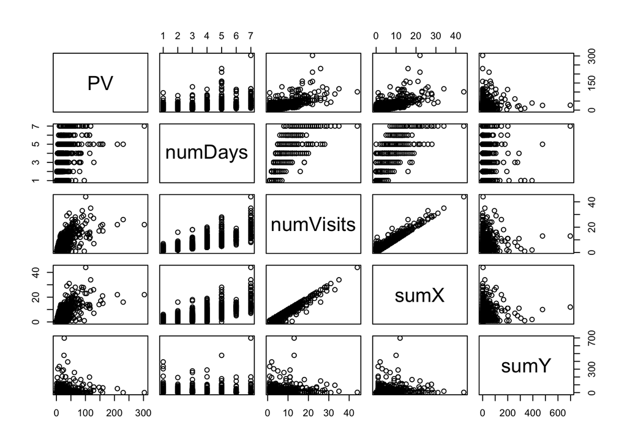

```r
# randomly select 5000 rows from pre-experiment control group
# convert metric columns to numeric for pairs function to visualize
df <- control_group %>%
  filter(IsPreExperiment == 1) %>%
  select(PV, numDays, numVisits, sumX, sumY) %>%
  sample_n(5000) %>%
  mutate(PV = as.numeric(PV),
         numDays = as.numeric(numDays),
         numVisits = as.numeric(numVisits))
pairs(df[, metric])
```

Calculating for all metrics except numDays itself:

```r
# calculate the stratified variance
# IsPreExperiment == 0 group only
control_total_count <- length(control_group$IsPreExperiment == 0)
test_total_count <- length(test_group$IsPreExperiment == 0)

# calculate weights using combined data from AA and AB
weights <- table(userLevel[userLevel$IsPreExperiment == 0, 'numDays']) /
  sum(userLevel$IsPreExperiment == 0)
weights <- data.frame(numDays = names(weights), wk = as.vector(weights))

# initialize vectors
test_stat <- NULL
p_value_strat <- NULL

for(cur_metric in 1:length(metric)){
  # calculate mean and var/n_per_strat for control group stratified by numDays
  # then merge weight information
  control_group %>%
    filter(IsPreExperiment == 0) %>%
    group_by(numDays) %>%
    dplyr::summarize_(mean_metric_c = paste0('mean(', metric[cur_metric], ')'),
                      var_metric_c = paste0('sum((', metric[cur_metric], ' - mean_metric_c)**2) / n()')) ->
    control_strat
  control_strat <- merge(control_strat, weights, by = 'numDays')

  # calculate mean and var for control group stratified by numDays
  test_group %>%
    filter(IsPreExperiment == 0) %>%
    group_by(numDays) %>%
    dplyr::summarize_(mean_metric_t = paste0('mean(', metric[cur_metric], ')'),
                      var_metric_t = paste0('sum((', metric[cur_metric], ' - mean_metric_t)**2) / n()')) ->
    test_strat

  # merge test and control data
  # combine test and control data by numDay categories, calculate mean difference and total variance
  #   -mean diff sum of weight * (control_mean_per_strat - test_mean_per_strat)
  #   -variance is similarly calculated for var_control and var_test, then combined using
  #    var(all) = var(control) / n_control + var(test) / n_test
  # test statistic is mean diff / sqrt(var)
  comb_strat <- merge(control_strat, test_strat, by = 'numDays')
  mean_diff <- sum(comb_strat$wk * (comb_strat$mean_metric_c - comb_strat$mean_metric_t))
  sd_all <- sqrt(sum(comb_strat$var_metric_t * comb_strat$wk) / sum(test_group$IsPreExperiment == 0) +
                   sum(comb_strat$var_metric_c * comb_strat$wk) / sum(control_group$IsPreExperiment == 0))
  test_stat[cur_metric] <- mean_diff / sd_all
  p_value_strat[cur_metric] <- ifelse(pnorm(test_stat[cur_metric]) >= .5,
                                      1 - pnorm(test_stat[cur_metric]),
                                      pnorm(test_stat[cur_metric]))
}

names(p_value_strat) <- metric
print(p_value_strat)
```

```
##          PV     numDays   numVisits        sumX        sumY
## 0.192415888          NA 0.420262378 0.005811641 0.000992355
```

Apply the same logic to numDays using PV as stratification, and backfill the vector. Note that there are 410 unique categories to PV stratification.

```r
idx <- which(metric == 'numDays')

# calculate weights using combined data from AA and AB
weights <- table(userLevel[userLevel$IsPreExperiment == 0, 'PV']) /
  sum(userLevel$IsPreExperiment == 0)
weights <- data.frame(PV = names(weights), wk = as.vector(weights))

# calculate mean and var/n_per_strat for control group stratified by PV specific for numDays metric
# then merge weight information
control_group %>%
  filter(IsPreExperiment == 0) %>%
  group_by(PV) %>%
  dplyr::summarize_(mean_metric_c = paste0('mean(', metric[idx], ')'),
                    var_metric_c = paste0('sum((', metric[idx], ' - mean_metric_c)**2) / n()')) ->
  control_strat
control_strat <- merge(control_strat, weights, by = 'PV')

# calculate mean and var for control group stratified by PV
test_group %>%
  filter(IsPreExperiment == 0) %>%
  group_by(PV) %>%
  dplyr::summarize_(mean_metric_t = paste0('mean(', metric[idx], ')'),
                    var_metric_t = paste0('sum((', metric[idx], ' - mean_metric_t)**2) / n()')) ->
  test_strat

comb_strat <- merge(control_strat, test_strat, by = 'PV')
mean_diff <- sum(comb_strat$wk * (comb_strat$mean_metric_c - comb_strat$mean_metric_t))
sd_all <- sqrt(sum(comb_strat$var_metric_t * comb_strat$wk) / sum(test_group$IsPreExperiment == 0) +
                 sum(comb_strat$var_metric_c * comb_strat$wk) / sum(control_group$IsPreExperiment == 0))
test_stat[idx] <- mean_diff / sd_all
p_value_strat[idx] <- ifelse(pnorm(test_stat[idx]) >= .5,
                             1 - pnorm(test_stat[idx]),
                             pnorm(test_stat[idx]))

p_value_strat
```

```
##          PV     numDays   numVisits        sumX        sumY
## 0.192415888 0.265236648 0.420262378 0.005811641 0.000992355
```

```r
strat_results <- p_value_strat < alpha
names(strat_results) <- names(p_value_strat)
```

### 3b. Comparing stratified p_values to normal t-testing

Comparing between the p-values from straight up individual hypothesis testing, stratification has reduced variance and resulted in smaller p-values.

```r
#Normal p-values by T/Wald test
results[metric]
```

```
##          PV     numDays   numVisits        sumX        sumY
## 0.555329099 0.482475356 0.886677022 0.114377421 0.001568191
```

```r
#Compare to stratified p-values
p_value_strat[metric]
```

```
##          PV     numDays   numVisits        sumX        sumY
## 0.192415888 0.265236648 0.420262378 0.005811641 0.000992355
```

## 4. Paper 1 Bayesian hypothesis testing

### 4a. Estimating initial p and V

Here we take use of the pre-experimental data to estimate both p and V using resampling.

```r
# grab only the pre-experiment data and calculate total count (for variance calculations later)
control_group_pre <- control_group %>%
  filter(IsPreExperiment == 1)
n_control_pre <- dim(control_group_pre)[1]
test_group_pre <- test_group %>%
  filter(IsPreExperiment == 1)
n_test_pre <- dim(test_group_pre)[1]

# set resample number
n_bootstrap_runs <- 300

# initialize
p <- NULL
V2 <- NULL

# boot strap for every metric
for(cur_metric in 1:length(metric)){
  # initialize
  z_stat <- NULL
  record_sigma <- NULL


  for(cur_iter in 1:n_bootstrap_runs){
    # sample with replacement
    control_sample <- sample(n_control_pre, n_control_pre, replace = TRUE)
    test_sample <- sample(n_test_pre, n_test_pre, replace = TRUE)

    # calculate delta and sd according to paper equation section 3
    delta <- mean(control_group_pre[control_sample, metric[cur_metric]]) -
      mean(test_group_pre[test_sample, metric[cur_metric]])

    sigma <- sqrt(var(control_group_pre[control_sample, metric[cur_metric]]) / n_control_pre +
                    var(test_group_pre[test_sample, metric[cur_metric]]) / n_test_pre)

    # record the z-statistic and sigma for each run
    z_stat[cur_iter] <- delta / sigma
    record_sigma[cur_iter] <- sigma
  }

  # for each metric, calculate the average times we reject hypothesis (p) and
  # average variance for all the runs (V2)
  p[cur_metric] <- mean(pnorm(z_stat) <= 0.05)
  V2[cur_metric] <- mean(record_sigma ** 2)
}

names(p) <- metric
names(V2) <- metric

p
```

```
##        PV   numDays numVisits      sumX      sumY
## 0.3866667 0.0600000 0.3066667 0.1466667 0.0700000
```

```r
V2
```

```
##           PV      numDays    numVisits         sumX         sumY
## 2.466762e-03 1.288109e-05 1.064341e-04 9.185767e-05 5.079504e-03
```

Taking the alpha0 equation from the handwritten lecture’s notes (page 35),

```r
# calculate number Nc, Nt, and Ne. Then compute V2 + sigma2/n
n_control_post <- sum(control_group$IsPreExperiment == 0)
n_test_post <- sum(test_group$IsPreExperiment == 0)
Ne <- 1 / (1 / n_test_post + 1 / n_control_post)
marginal_variance <- V2 + 1 / Ne

# calculate pi0/pi1, mean and variances
pi0_over_pi1 <- (1 - p) / p

mean_control_post <- control_group %>%
  filter(IsPreExperiment == 0) %>%
  select(PV, numDays, numVisits, sumX, sumY) %>%
  summarize_all(mean)

mean_test_post <- test_group %>%
  filter(IsPreExperiment == 0) %>%
  select(PV, numDays, numVisits, sumX, sumY) %>%
  summarize_all(mean)

var_control_post <- control_group %>%
  filter(IsPreExperiment == 0) %>%
  select(PV, numDays, numVisits, sumX, sumY) %>%
  summarise(var_PV = (sum((PV - mean(PV)) ** 2))  / n_control_post,
            var_numDays = (sum((numDays - mean(numDays)) **2)) / n_control_post,
            var_numVisits = (sum((numVisits - mean(numVisits)) **2)) / n_control_post,
            var_sumX = (sum((sumX - mean(sumX)) **2)) / n_control_post,
            var_sumY = (sum((sumY - mean(sumY)) **2)) / n_control_post)

var_test_post <- test_group %>%
  filter(IsPreExperiment == 0) %>%
  select(PV, numDays, numVisits, sumX, sumY) %>%
  summarise(var_PV = (sum((PV - mean(PV)) ** 2))  / n_test_post,
            var_numDays = (sum((numDays - mean(numDays)) **2)) / n_test_post,
            var_numVisits = (sum((numVisits - mean(numVisits)) **2)) / n_test_post,
            var_sumX = (sum((sumX - mean(sumX)) **2)) / n_test_post,
            var_sumY = (sum((sumY - mean(sumY)) **2)) / n_test_post)

# use above to calculate the mu and sd
pooled_sd <- sqrt(Ne * (var_control_post + var_test_post))
x_bar <- (mean_control_post - mean_test_post) / pooled_sd

# since this is a test on whether delta is zero, so theta0 = 0
alpha0 <- (1 + pi0_over_pi1 * exp(0.5 * ((x_bar * Ne) ** 2) / (1 +  1 / (V2 * Ne))) / sqrt (1 + Ne * V2)) **(-1)

alpha0
```

```
##             PV    numDays numVisits     sumX      sumY
## [1,] 0.9120498 0.08812484 0.6290709 0.258145 0.1376727
```

```r
# the probability of alpha 1 happening is
1 - alpha0
```

```
##              PV   numDays numVisits     sumX      sumY
## [1,] 0.08795017 0.9118752 0.3709291 0.741855 0.8623273
```

```r
# so the metrics where null hypothesis is rejected is where the probability of null hypothesis is
# larger than the probability of alternative hypothesis
# In this case, three metrics are rejected instead: numDays, sumX, sumY
(1 - alpha0) > alpha0
```

```
##         PV numDays numVisits sumX sumY
## [1,] FALSE    TRUE     FALSE TRUE TRUE
```

```r
bayes_results <- as.vector((1 - alpha0) > alpha0)
names(bayes_results) <- names(mean_control_post)
```

## 5. Comparing the different hypothesis testing methods

Here we see Hochberg and Holm arrive as the same conclusion that only sumY’s null hypothesis can be rejected. Stratification which reduces variance, and thus reduces the p-values have rejected the null hypothesis for both sumX and sumY. In comparison, Bayesian method has rejected all three: sumX, sumY and numDays!

```r
all_results <- data.frame(Hochberg = Hochberg_results[metric],
                          Holm = Holm_results[metric],
                          Stratification = !strat_results[metric],
                          Bayesian = !bayes_results[metric])
all_results
```

```
##           Hochberg  Holm Stratification Bayesian
## PV            TRUE  TRUE           TRUE     TRUE
## numDays       TRUE  TRUE           TRUE    FALSE
## numVisits     TRUE  TRUE           TRUE     TRUE
## sumX          TRUE  TRUE          FALSE    FALSE
## sumY         FALSE FALSE          FALSE    FALSE
```